# Statistical Learning R Project

Carlos Segovia

2022-12-17

## INTRODUCTION

This is a stock prediction statistical analysis project. The goal is to predict whether AT&T will be up or down in the market using several predictors.The dataset is from a reliable and from a well cited public source, Kaggle. However, the dataset is not current; but it is comprehensive to begin our analysis with R.

## PROCESSING

First, the data set has percentage returns for AT&T (NYSE: T) stock over 1,754 days, from beginning of 2010 until 2016. Using a spreadsheet; for each date, the percentage returns for each of the five previous trading days, Lag1 through Lag5, are calculated. The Volume (number of shares traded on previous day, in 10 millions.) for each of the three previous trading days, Vol1 through Vol3, are calculated. We have Today (percentage return on the date in question) and Direction (whether the stock was Up [1] or Down [0] on the date and our response). Also included are the volumes and percentage returns for competitor Verizon (NYSE: VZ) and big tech company Apple (NYSE: AAPL). Their respective labels in the data set has the company’s ticker symbol as suffix.

### Viewing Data

Using R, we can view the dimensions of the dataset. In addition, a table can be created using the library knitr and the kable() function. For example, the dataset has the following dimensions, and the first 10 rows and first 10 predictors are shown.

```
## [1] 1754   19
```

A knitr kable

| date | today | direction | vol10M | vol_lag1 | vol_lag2 | lag1 | lag2 | lag3 | lag4 |
| --- | --- | --- | --- | --- | --- | --- | --- | --- | --- |
| 2016 | 0.0054079 | 1 | 1.23892 | 1.10269 | 1.14327 | -0.0030474 | 0.0030574 | 0.0018757 | 0.0014042 |
| 2016 | -0.0030474 | 0 | 1.10269 | 1.14327 | 0.96454 | 0.0030574 | 0.0018757 | 0.0014042 | -0.0112359 |
| 2016 | 0.0030574 | 1 | 1.14327 | 0.96454 | 1.75606 | 0.0018757 | 0.0014042 | -0.0112359 | 0.0014164 |
| 2016 | 0.0018757 | 1 | 0.96454 | 1.75606 | 1.37530 | 0.0014042 | -0.0112359 | 0.0014164 | -0.0070639 |
| 2016 | 0.0014042 | 1 | 1.75606 | 1.37530 | 2.11644 | -0.0112359 | 0.0014164 | -0.0070639 | -0.0106838 |
| 2016 | -0.0112359 | 0 | 1.37530 | 2.11644 | 2.05639 | 0.0014164 | -0.0070639 | -0.0106838 | -0.0004799 |
| 2016 | 0.0014164 | 1 | 2.11644 | 2.05639 | 2.79545 | -0.0070639 | -0.0106838 | -0.0004799 | -0.0144578 |
| 2016 | -0.0070639 | 0 | 2.05639 | 2.79545 | 2.44866 | -0.0106838 | -0.0004799 | -0.0144578 | 0.0048662 |
| 2016 | -0.0106838 | 0 | 2.79545 | 2.44866 | 2.63334 | -0.0004799 | -0.0144578 | 0.0048662 | -0.0021760 |
| 2016 | -0.0004799 | 0 | 2.44866 | 2.63334 | 2.11599 | -0.0144578 | 0.0048662 | -0.0021760 | -0.0136186 |

### Checking for Nulls

Part of the processing phase for data analysis is data cleaning. One example is checking for nulls, which is missing data. It can be done with the supply() function in R. We can conclude that there are no nulls in the dataset.

```
##             date            today        direction           vol10M
##                0                0                0                0
##         vol_lag1         vol_lag2             lag1             lag2
##                0                0                0                0
##             lag3             lag4             lag5         today_vz
##                0                0                0                0
##        vol10M_vz   vol10M_vz_lag1   vol10M_vz_lag2       today_aapl
##                0                0                0                0
##      vol10M_aapl vol10M_aapl_lag1 vol10M_aapl_lag2
##                0                0                0
```

## ANALYSIS

The corr() function provides correlation analysis of the observations. It gives numerical values between -1 and 1; where values closer to the endpoints can have a correlation. We will illustrate the results visually using the corrplot() function, it is found in the corrplot library.

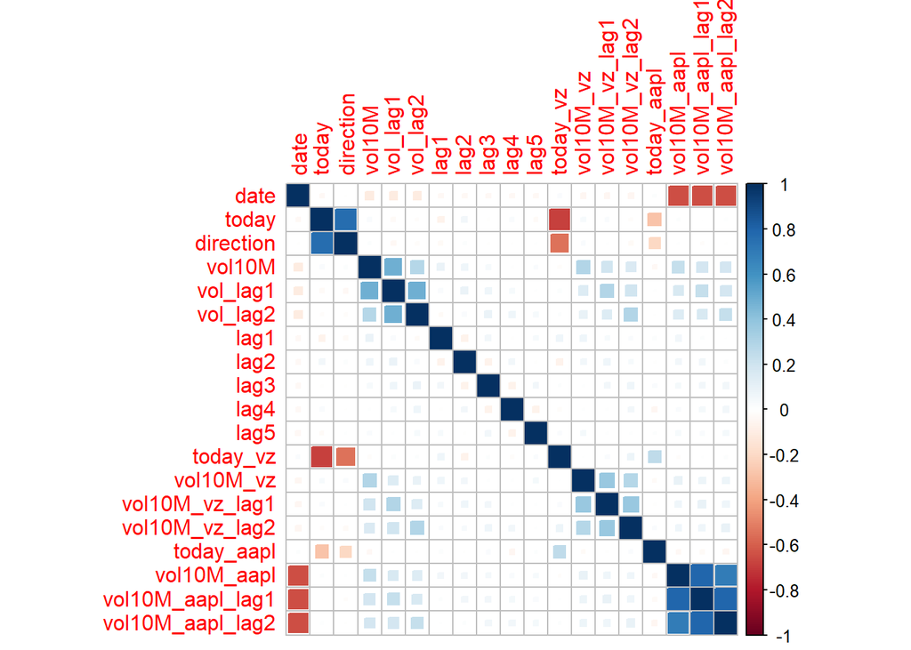

Using scatter plots, we can further investigate our correlations. We can see some linear relationship between the response and predictors.

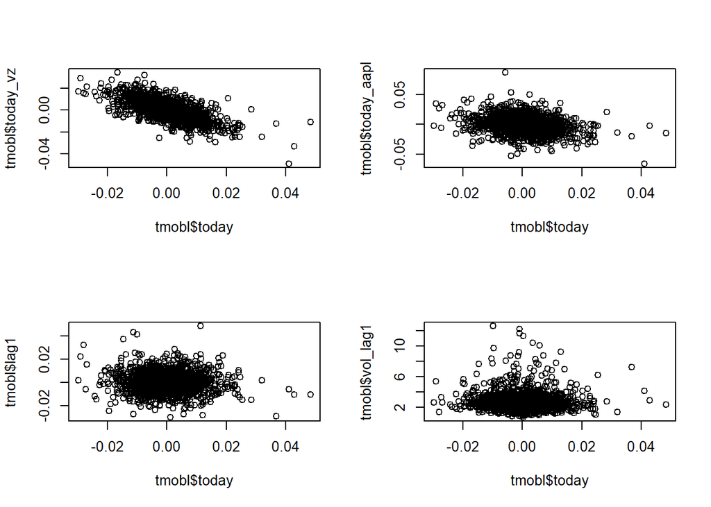

## MODELING

### Data Partitioning

We want to test our data with unseen data from the training dataset used to fit our models. Therefore, we partition the data with the training set consisting of observations prior to the year 2015. The testing set will have observations after the year 2015. The dimensions of the training set and testing set are the following, respectively:

```
## [1] 1250   18
```

```
## [1] 504  18
```

### Best Subset Selection

The function regsubsets() from the leaps library is used to select the best model that contains given number of predictors. Best is quantified using RSS, residual sum of squares.

```
## Subset selection object
## Call: regsubsets.formula(tmobl_n$direction ~ ., data = tmobl_n, nvmax = 17,
##     method = "forward")
## 17 Variables  (and intercept)
##                  Forced in Forced out
## date                 FALSE      FALSE
## vol10M               FALSE      FALSE
## vol_lag1             FALSE      FALSE
## vol_lag2             FALSE      FALSE
## lag1                 FALSE      FALSE
## lag2                 FALSE      FALSE
## lag3                 FALSE      FALSE
## lag4                 FALSE      FALSE
## lag5                 FALSE      FALSE
## today_vz             FALSE      FALSE
## vol10M_vz            FALSE      FALSE
## vol10M_vz_lag1       FALSE      FALSE
## vol10M_vz_lag2       FALSE      FALSE
## today_aapl           FALSE      FALSE
## vol10M_aapl          FALSE      FALSE
## vol10M_aapl_lag1     FALSE      FALSE
## vol10M_aapl_lag2     FALSE      FALSE
## 1 subsets of each size up to 17
## Selection Algorithm: forward
##           date vol10M vol_lag1 vol_lag2 lag1 lag2 lag3 lag4 lag5 today_vz
## 1  ( 1 )  " "  " "    " "      " "      " "  " "  " "  " "  " "  "*"
## 2  ( 1 )  " "  " "    " "      " "      " "  " "  " "  " "  " "  "*"
## 3  ( 1 )  " "  " "    "*"      " "      " "  " "  " "  " "  " "  "*"
## 4  ( 1 )  " "  " "    "*"      " "      " "  " "  " "  " "  " "  "*"
## 5  ( 1 )  " "  "*"    "*"      " "      " "  " "  " "  " "  " "  "*"
## 6  ( 1 )  " "  "*"    "*"      " "      " "  " "  " "  " "  "*"  "*"
## 7  ( 1 )  " "  "*"    "*"      " "      " "  "*"  " "  " "  "*"  "*"
## 8  ( 1 )  " "  "*"    "*"      " "      " "  "*"  " "  " "  "*"  "*"
## 9  ( 1 )  " "  "*"    "*"      " "      " "  "*"  " "  "*"  "*"  "*"
## 10  ( 1 ) " "  "*"    "*"      " "      " "  "*"  " "  "*"  "*"  "*"
## 11  ( 1 ) " "  "*"    "*"      " "      " "  "*"  " "  "*"  "*"  "*"
## 12  ( 1 ) " "  "*"    "*"      " "      " "  "*"  " "  "*"  "*"  "*"
## 13  ( 1 ) " "  "*"    "*"      "*"      " "  "*"  " "  "*"  "*"  "*"
## 14  ( 1 ) "*"  "*"    "*"      "*"      " "  "*"  " "  "*"  "*"  "*"
## 15  ( 1 ) "*"  "*"    "*"      "*"      " "  "*"  " "  "*"  "*"  "*"
```

[output cut: 23 more lines]

```
## 3  ( 1 )  " "              " "
## 4  ( 1 )  " "              " "
## 5  ( 1 )  " "              " "
## 6  ( 1 )  " "              " "
## 7  ( 1 )  " "              " "
## 8  ( 1 )  " "              " "
## 9  ( 1 )  " "              " "
## 10  ( 1 ) " "              " "
## 11  ( 1 ) "*"              " "
## 12  ( 1 ) "*"              "*"
## 13  ( 1 ) "*"              "*"
## 14  ( 1 ) "*"              "*"
## 15  ( 1 ) "*"              "*"
## 16  ( 1 ) "*"              "*"
## 17  ( 1 ) "*"              "*"
```

```
## [1] "which"  "rsq"    "rss"    "adjr2"  "cp"     "bic"    "outmat" "obj"
```

```
##  [1] 0.2923024 0.2971461 0.2978619 0.2985661 0.2990259 0.2993355 0.2995924
##  [8] 0.2997456 0.2998860 0.2999511 0.3000138 0.3002027 0.3002538 0.3002923
## [15] 0.3003307 0.3003526 0.3003532
```

We notice the r squared statistics increases motonically as more variables are used. Also, we see the best model contains 2 variables - which are the competitors stock pricing of Verizon (VZ) and Apple (AAPL).

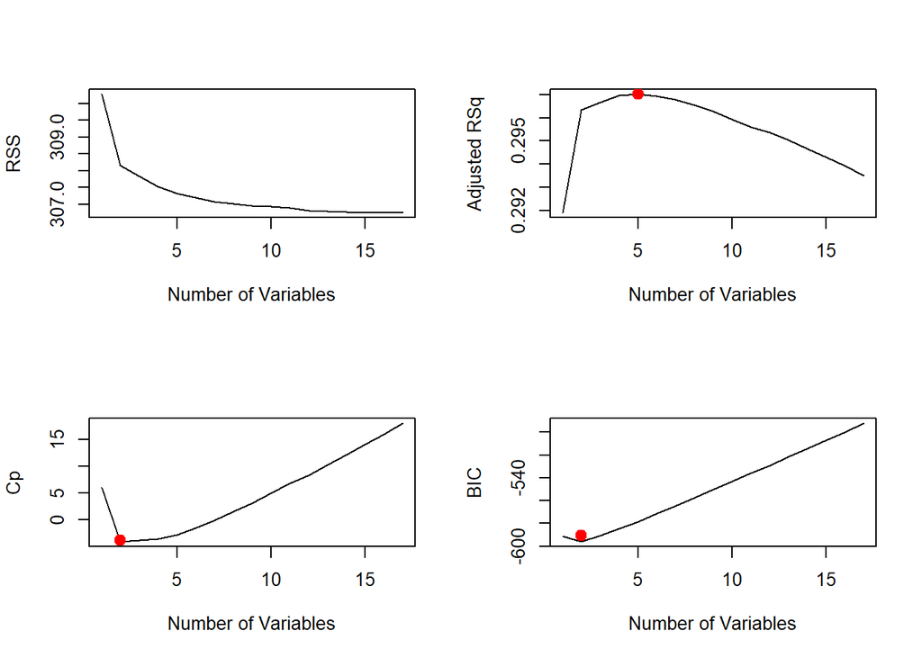

## Multiple Linear Regression

We interpret the coefficients as the average effect on the direction of our stock price of a unit increase on its associated predictor. Holding all other predictors fixed.

```
##
## Call:
## lm(formula = tmobl_n$direction ~ ., data = tmobl_n, subset = train)
##
## Residuals:
##      Min       1Q   Median       3Q      Max
## -1.32040 -0.37014 -0.02288  0.36809  1.01611
##
## Coefficients:
##                    Estimate Std. Error t value Pr(>|t|)
## (Intercept)      -2.022e+01  2.012e+01  -1.005 0.315109
## date              1.030e-02  9.990e-03   1.031 0.302717
## vol10M            1.244e-02  1.183e-02   1.051 0.293414
## vol_lag1         -2.150e-02  1.285e-02  -1.673 0.094506 .
## vol_lag2         -6.911e-03  1.182e-02  -0.585 0.558789
## lag1              3.771e-01  1.511e+00   0.250 0.803002
## lag2             -1.036e+00  1.508e+00  -0.687 0.492493
## lag3             -1.066e+00  1.502e+00  -0.710 0.478046
## lag4             -7.615e-02  1.493e+00  -0.051 0.959342
## lag5              1.686e+00  1.487e+00   1.134 0.257164
## today_vz         -2.967e+01  1.420e+00 -20.892  < 2e-16 ***
## vol10M_vz         4.227e-03  6.882e-03   0.614 0.539251
## vol10M_vz_lag1    5.785e-03  7.083e-03   0.817 0.414198
## vol10M_vz_lag2    7.434e-04  6.925e-03   0.107 0.914522
## today_aapl       -3.030e+00  9.152e-01  -3.310 0.000958 ***
## vol10M_aapl       9.867e-04  3.047e-03   0.324 0.746132
## vol10M_aapl_lag1 -2.166e-03  3.548e-03  -0.610 0.541670
## vol10M_aapl_lag2  2.589e-03  3.069e-03   0.844 0.398969
## ---
## Signif. codes:  0 '***' 0.001 '**' 0.01 '*' 0.05 '.' 0.1 ' ' 1
##
## Residual standard error: 0.4225 on 1232 degrees of freedom
## Multiple R-squared:  0.2963, Adjusted R-squared:  0.2866
## F-statistic: 30.52 on 17 and 1232 DF,  p-value: < 2.2e-16
```

The lower the p-value, it would mean that our null hypothesis is incorrect. Therefore, there is a strong correlation to our response. We can now validate our model to our test dataset using the 2 strong predictors of stock price from our competitors. To make predictions whether our stock goes up or down in particular day, we create vector of class predictions. Then based on whether predicted probabilities of the stock increase > or < 0.5.

Finally, computing the Confusion matrix, where the diagonals indicate correct predictions, off-diagonals representing incorrect predictions. Another way to measure accuracy, fraction days which predict was correct.

```
##              direction.2015
## mlr.pred.test   0   1
##             0 198  57
##             1  64 185
```

```
## [1] 0.7599206
```

## Logistic Regression

Now we run a logistic regression in R. The argument “family = binomial” must be passed to run logistic regression rather some other type of generalized linear model.

```
##
## Call:
## glm(formula = direction ~ ., family = binomial, data = tmobl_n,
##     subset = train)
##
## Deviance Residuals:
##     Min       1Q   Median       3Q      Max
## -3.2531  -0.8670  -0.0304   0.8321   2.6044
##
## Coefficients:
##                    Estimate Std. Error z value Pr(>|z|)
## (Intercept)      -1.124e+02  1.150e+02  -0.977 0.328448
## date              5.591e-02  5.712e-02   0.979 0.327716
## vol10M            8.459e-02  7.755e-02   1.091 0.275399
## vol_lag1         -1.596e-01  7.838e-02  -2.036 0.041771 *
## vol_lag2          2.907e-02  7.721e-02   0.376 0.706558
## lag1              4.944e-01  9.071e+00   0.055 0.956531
## lag2             -5.773e+00  8.835e+00  -0.653 0.513491
## lag3             -1.087e+01  8.976e+00  -1.211 0.226016
## lag4              2.406e-01  8.700e+00   0.028 0.977942
## lag5              1.333e+01  8.758e+00   1.522 0.127943
## today_vz         -1.882e+02  1.204e+01 -15.628  < 2e-16 ***
## vol10M_vz         4.622e-02  9.048e-02   0.511 0.609467
## vol10M_vz_lag1    3.946e-02  4.842e-02   0.815 0.415169
## vol10M_vz_lag2   -1.000e-01  9.970e-02  -1.003 0.315866
## today_aapl       -2.129e+01  5.529e+00  -3.850 0.000118 ***
## vol10M_aapl       5.151e-03  1.756e-02   0.293 0.769196
## vol10M_aapl_lag1 -1.225e-02  2.059e-02  -0.595 0.552036
## vol10M_aapl_lag2  1.440e-02  1.800e-02   0.800 0.423731
## ---
## Signif. codes:  0 '***' 0.001 '**' 0.01 '*' 0.05 '.' 0.1 ' ' 1
##
## (Dispersion parameter for binomial family taken to be 1)
##
##     Null deviance: 1732.9  on 1249  degrees of freedom
## Residual deviance: 1268.6  on 1232  degrees of freedom
## AIC: 1304.6
##
## Number of Fisher Scoring iterations: 5
```

We can see again that competitor stock price has the strongest correlation, having the lowest p-value. However, the previous volume of our stock shares(vol_lag1) is below the 5% rule of thumb for it to considered as correlating. Next we test our model by making predictions and checking the mean, percentage of time our model is correct.

```
##
## Call:
## glm(formula = direction ~ vol_lag1 + today_vz + today_aapl, family = binomial,
##     data = tmobl_n, subset = train)
##
## Deviance Residuals:
##     Min       1Q   Median       3Q      Max
## -3.1928  -0.8750  -0.0563   0.8574   2.7237
##
## Coefficients:
##               Estimate Std. Error z value Pr(>|z|)
## (Intercept)    0.31469    0.16535   1.903   0.0570 .
## vol_lag1      -0.11599    0.05767  -2.011   0.0443 *
## today_vz    -186.06397   11.89529 -15.642  < 2e-16 ***
## today_aapl   -21.89777    5.47503  -4.000 6.35e-05 ***
## ---
## Signif. codes:  0 '***' 0.001 '**' 0.01 '*' 0.05 '.' 0.1 ' ' 1
##
## (Dispersion parameter for binomial family taken to be 1)
##
##     Null deviance: 1732.9  on 1249  degrees of freedom
## Residual deviance: 1278.6  on 1246  degrees of freedom
## AIC: 1286.6
##
## Number of Fisher Scoring iterations: 5
```

```
##             direction.2015
## glm.pred.fin   0   1
##            0 196  56
##            1  66 186
```

```
## [1] 0.7579365
```

```
## [1] 0.7579365
```

## Other Models

Other statistical models will be computed to view their accuracy and compare to the previous models. At first, the models will be ran with all predictors and the accuracy will be computed. Then the model with the highest mean value will be optimized.

### LDA

Linear Discriminant Analysis (LDA) is part of the MASS library. LDA output shows “pi1” 0.50 & “pi2” 0.499; tells us that 50% train observations correlate to days att stock price (today) is down. Also the group means and the coefficients are displayed.

```
## Call:
## lda(direction ~ ., data = tmobl_n, subset = train)
##
## Prior probabilities of groups:
##      0      1
## 0.5008 0.4992
##
## Group means:
##       date   vol10M vol_lag1 vol_lag2         lag1         lag2          lag3
## 0 2011.979 2.626651 2.718031 2.675959 3.626435e-04 9.721746e-05  0.0005108148
## 1 2012.046 2.671146 2.581707 2.626010 3.028381e-06 2.622964e-04 -0.0001382689
##           lag4         lag5     today_vz vol10M_vz vol10M_vz_lag1
## 0 5.222804e-05 7.239815e-05  0.004671142  1.645523       1.696779
## 1 3.386514e-04 3.320218e-04 -0.004586473  1.768591       1.717879
##   vol10M_vz_lag2   today_aapl vol10M_aapl vol10M_aapl_lag1 vol10M_aapl_lag2
## 0       1.779686  0.002263366    11.41116         11.53643         11.47425
## 1       1.636805 -0.002901681    11.36209         11.25545         11.33192
##
## Coefficients of linear discriminants:
##                            LD1
## date              4.507524e-02
## vol10M            5.443846e-02
## vol_lag1         -9.408016e-02
## vol_lag2         -3.024646e-02
## lag1              1.650136e+00
## lag2             -4.532248e+00
## lag3             -4.665869e+00
## lag4             -3.332649e-01
## lag5              7.377358e+00
## today_vz         -1.298271e+02
## vol10M_vz         1.849648e-02
## vol10M_vz_lag1    2.531931e-02
## vol10M_vz_lag2    3.253360e-03
## today_aapl       -1.325852e+01
## vol10M_aapl       4.318325e-03
## vol10M_aapl_lag1 -9.479889e-03
## vol10M_aapl_lag2  1.133207e-02
```

```
##          direction.2015
## lda.class   0   1
##         0 189  49
##         1  73 193
```

```
## [1] 0.7579365
```

### Best LDA

We include the best 2 variables to the LDA model and determine the accuracy.

```
## Call:
## lda(direction ~ today_vz + today_aapl, data = tmobl_n, subset = train)
##
## Prior probabilities of groups:
##      0      1
## 0.5008 0.4992
##
## Group means:
##       today_vz   today_aapl
## 0  0.004671142  0.002263366
## 1 -0.004586473 -0.002901681
##
## Coefficients of linear discriminants:
##                   LD1
## today_vz   -130.19794
## today_aapl  -13.84474
```

```
##           direction.2015
## lda.class2   0   1
##          0 198  57
##          1  64 185
```

```
## [1] 0.7599206
```

### QDA

At 65.9% correct prediction rate, it is lower than previous models. One conclusion is that our dataset is not quadratic.

```
##          direction.2015
## qda.class   0   1
##         0 236 146
##         1  26  96
```

```
## [1] 0.6587302
```

```
## [1] 0.6587302
```

### Naives Bayes

```
##         direction.2015
## nb.class   0   1
##        0 216 101
##        1  46 141
```

```
## [1] "(216+141)/504= 0.708333333333333"
```

```
## [1] "mean = 0.708333333333333"
```

### KNN

K-nearest neighbor function is part of the class library. It forms predictions using a single command and requires 4 inputs. They are: a matrix with predictors for training data; matrix with predictors for test data; vector containing class labels for training and value K number for nearest neighbors. Also, we the cbind() function to bind the competitor stock prices into 2 matrices, one for training and other for testing. Keep in mind to use set.seed(), because if several observations are tied as nearest neighbors, there will need to be a break of the tie. Thus, ensure reproduceability.

```
##         direction.2015
## knn.pred   0   1
##        0 172  84
##        1  90 158
```

```
## [1] 0.6547619
```

```
## [1] 0.6547619
```

### Best KNN

A for loop is used to find the best k number, hence the best KNN model will provided.

```
##  [1] 0.6547619 0.6746032 0.7103175 0.6964286 0.7123016 0.7380952 0.7519841
##  [8] 0.7321429 0.7400794 0.7420635 0.7440476 0.7579365 0.7400794
```

```
## [1] "max k= 12"
```

```
## [1] "max k mean= 0.757936507936508"
```

## Conclusion

It appears that a 2 variable model is the most ideal; as it provides the better fraction of days we correctly picked the direction of the stock price. In addition, the multiple linear and logistic regression models provided the better results. Thus our final model will have the following coefficients:

```
## [1] "Multiple Linear Regression"
```

```
## (Intercept)    today_vz  today_aapl
##   0.4996801 -29.5596553  -3.1432584
```

```
## [1] "Logistic Regression"
```

[output not shown]

Negative coefficients could mean if Verizon or Apple are negative today then less likely for AT&T to go up. It makes sense at first thought; however, now we have a statistical model to answer many more questions to to help our stock decisions.

## R Code

```
# Clear plots
if(!is.null(dev.list())) dev.off()
# Clear console
cat("\014")
# Clean workspace
rm(list=ls())

##Setting up the working directory
#setwd("")
#getwd()

##Reading the Data
tmobl <- read.csv("C:/.../.csv",header = TRUE)
attach(tmobl)
dim(tmobl)
View(tmobl)
summary(tmobl)
cor(tmobl)

## Check for missing data for each column
sapply(tmobl, function(x) sum(is.na(x)))

## Corrplot package
### Visual tool for correlation matrix.
library(corrplot)
corrplot(cor(tmobl), method="square")
dev.off()
par(mfrow=c(2,2))
plot(today, date)
plot(today, direction)
plot(today,today_vz)
plot(today,today_aapl)

#Remove Today from data
### Due to Direction variable being created from Today variable, it will be removed from further analysis.
tmobl_n <- within(tmobl, rm(today))
tmobl_n[1:4,]
dim(tmobl_n)

## Partition Data
```

[output cut: 152 more lines]

```
mean.knn.loop
which.max(mean.knn.loop)

## Random forest
library(randomForest)
set.seed(1)
bag.tmobl=randomForest(direction~.,data=tmobl_n,subset=train,mtry=13,importance=TRUE)
bag.tmobl
yhat.bag = predict(bag.tmobl,newdata=tmobl.2015)
plot(yhat.bag, direction.2015)
abline(0,1)
mean((yhat.bag-direction.2015)^2)

detach(tmobl)
#save.image("")
```